# Restitution propage

**Nom de la structure** : Bordeaux

**Première année de participation** : 2016

**Nombre d’espaces verts** : 27

**Nombre de transects** : 66

Nombre de taxons différents observés

[interactive chart not shown]

**Nombre d’individus observés depuis 2016** : **4171**

**Nombre d’habitats** : 8 sur 8 existants

**Habitats non présents :**

- Tous les habitats sont représentés

**Espèces communément observées :**

- Piérides blanches
- Tircis
- Lycènes bleus
- Myrtil
- Souci

**Espèces les plus rarement observées :**

- Grande Tortue
- Mars changeants
- Moirés
- Tristan
- Marbrés

Mon année

Pourcentage des données de la structure utilisées dans les référentiels régionaux

[interactive chart not shown]

On calcule parmi tous les transects protocolés de la région (utilisés dans le calcul du référentiel) quel pourcentage appartient à la structure, ce qui permet d’accéder au poids de la structure dans le calcul du référentiel auquel elle est comparée.

Représentation des différents habitats parmi les transects de la structure

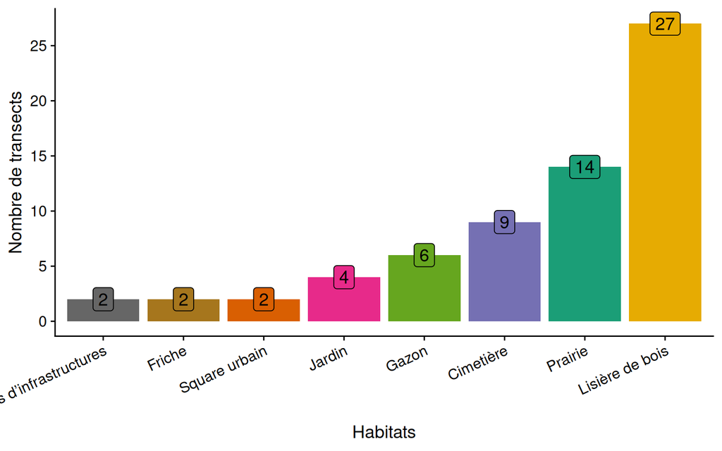

**Tous les taxons**

Proportion d’abondance de chaque taxon parmi toutes les observations de la structure

[interactive chart not shown]

**Top 5**

Taxons les plus représentés dans le relevé en terme d’abondance

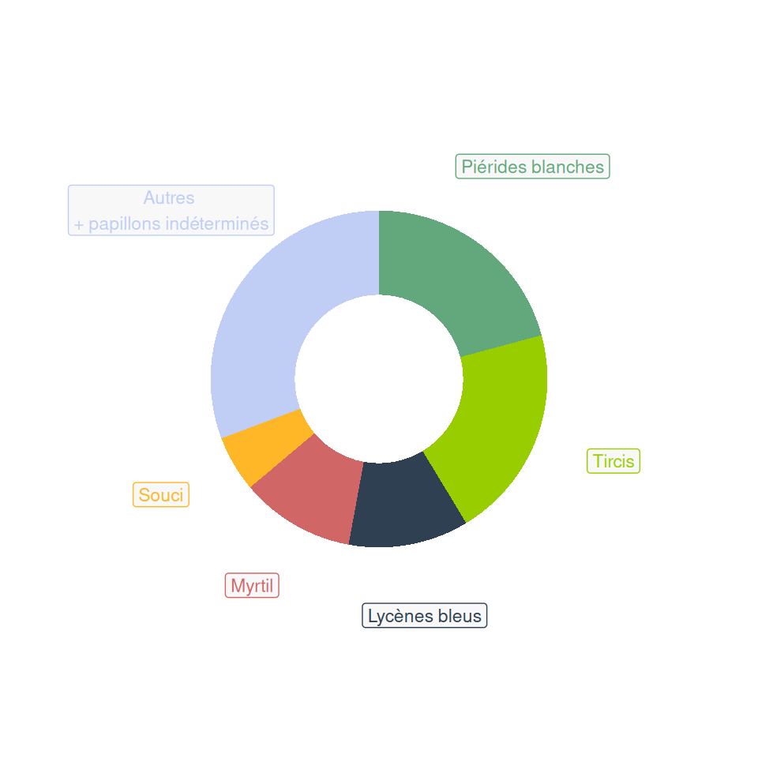

**Nombre de passages par an**

Nombre de transects suivis par an par la structure, coloré selon le nombre de passages effectués

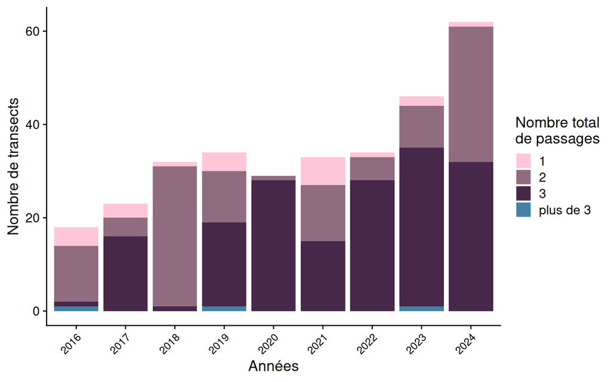

**Suivi temporel des transects**

Continuité de la participation des transects de la structure sur toute la période d’existence du protocole propage. (NB : liste des transects par ordre alphabétique ou groupement des transects par site)

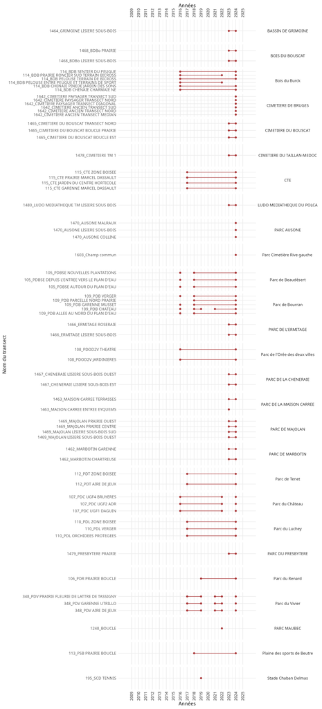

**Abondance totale**

Nombre total de papillons observés à l’échelle de la structure chaque année

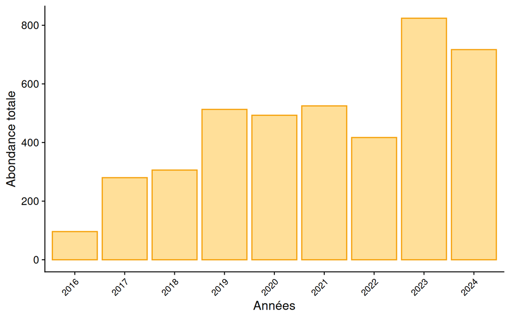

**Richesse totale**

Nombre total d’espèces de papillons observées à l’échelle de la structure chaque année

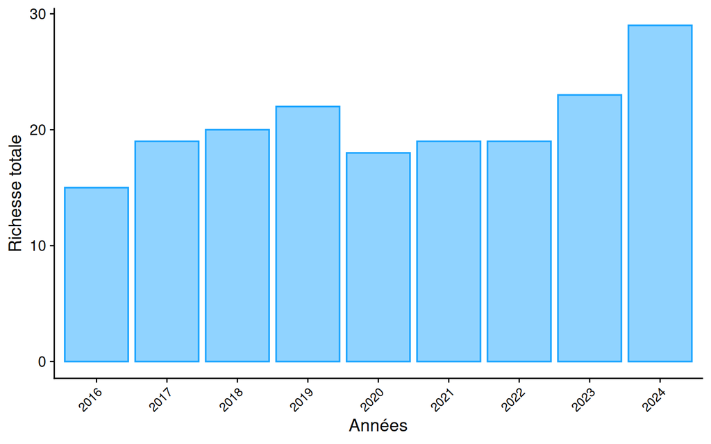

Nombre de sessions par an

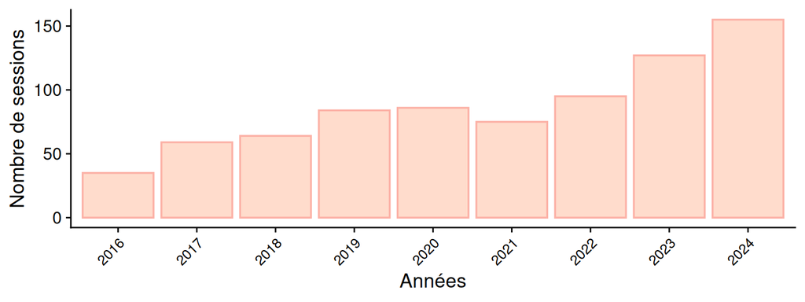

**Abondance totale**

Abondance totale par passage pour chaque transect dans les différents types d’habitats. On affiche tous les transects de la structure (sans distinction de respect ou non du protocole).

**Bords d’infrastructures**

```
Habitat non suivi
```

**Cimetière**

**Friche**

[interactive chart not shown]

**Gazon**

[interactive chart not shown]

**Jardin**

[interactive chart not shown]

**Lisière de bois**

[interactive chart not shown]

**Prairie**

[interactive chart not shown]

**Square urbain**

[interactive chart not shown]

**Richesse totale**

Richesse totale par transect pour chaque habitat. On affiche également en rouge pour un habitat la richesse totale annuelle (calculée à partir de tous les transects présents dans cet habitat). La valeur maximale de l’axe des ordonnées est fixée à la valeur maximale de la richesse sur l’ensemble des habitats, ce qui permet de comparer les habitats entre eux. Les données sont non protocolées.

**Bords d’infrastructures**

```
Habitat non suivi
```

**Cimetière**

**Friche**

[interactive chart not shown]

**Gazon**

[interactive chart not shown]

**Jardin**

[interactive chart not shown]

**Lisière de bois**

[interactive chart not shown]

**Prairie**

[interactive chart not shown]

**Square urbain**

[interactive chart not shown]

**Richesse cumulée**

Richesse relative par transect pour chaque habitat. Les données sont non protocolées.

**Bords d’infrastructures**

```
Habitat non suivi
```

**Cimetière**

**Friche**

[interactive chart not shown]

**Gazon**

[interactive chart not shown]

**Jardin**

[interactive chart not shown]

**Lisière de bois**

[interactive chart not shown]

**Prairie**

[interactive chart not shown]

**Square urbain**

[interactive chart not shown]

On montre les boxplots à partir des sessions effectuées dans chaque habitat.

**Abondance totale par habitat**

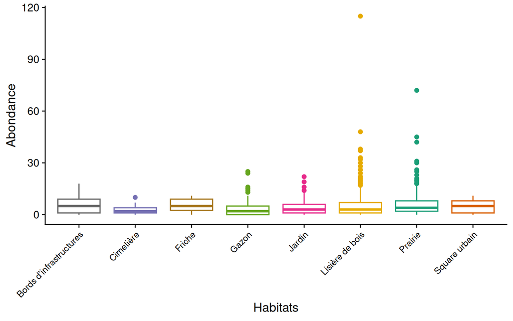

**Richesse totale par habitat**

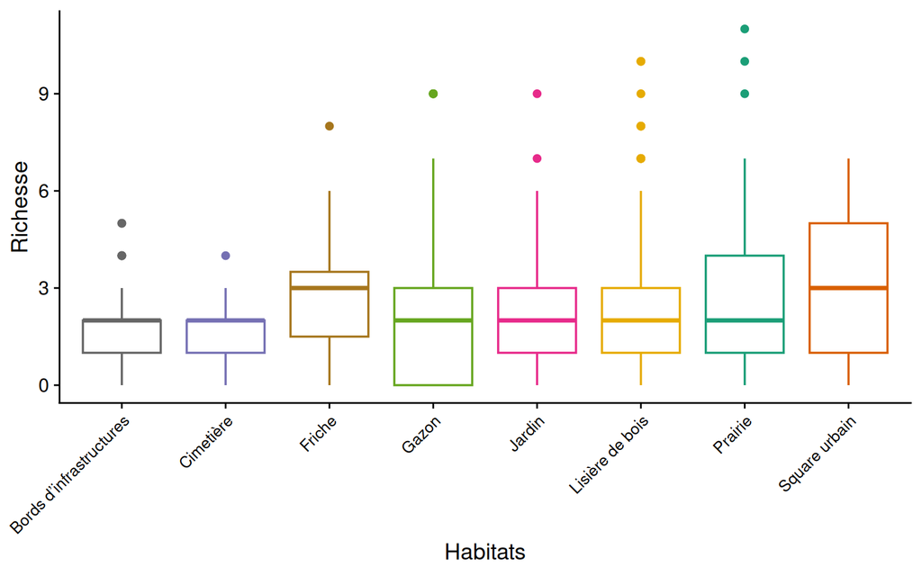

**NB** : Pour les calculs sur les données standardisées, on ne retient que les années où ont été effectuées les trois passages protocolés.

On ne garde que les passages 1, 2 et 3, les passages faits en plus ne sont pas pris en compte.

Pour les référentiels :

- Si les données de la structure représentent moins de 30% des données de la région, on utilise le **référentiel régional**
- Si les données de la structure représentent plus de 30% des données de la région, on utilise comme référentiel les **biogéorégions** (atlantique, alpine, continentale et méditerranéenne).

**Tendances de l’abondance**

Moyenne de l’abondance par passage (sur les données standardisées) :

5.12

Référentiel : 6.38

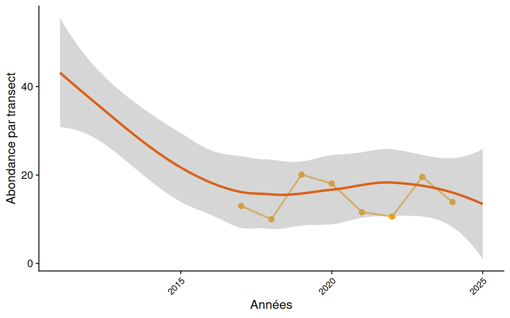

Pour les transects ayant respecté les trois passages protocolaires, on somme l’abondance obtenue lors des trois passages, puis on calcule à l’échelle de la structure l’abondance moyenne sur une année obtenue sur les différents transects. Cela permet d’avoir en moyenne combien de papillons seront observés sur un transect après les trois passages protocolés du propage.

**Tendances de la richesse**

Moyenne de la richesse par passage (sur les données standardisées) :

2.12

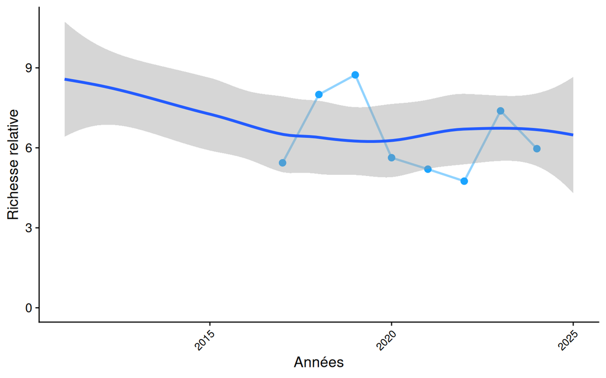

Pourcentage des données de la structure utilisées dans le calcul du référentiel par année

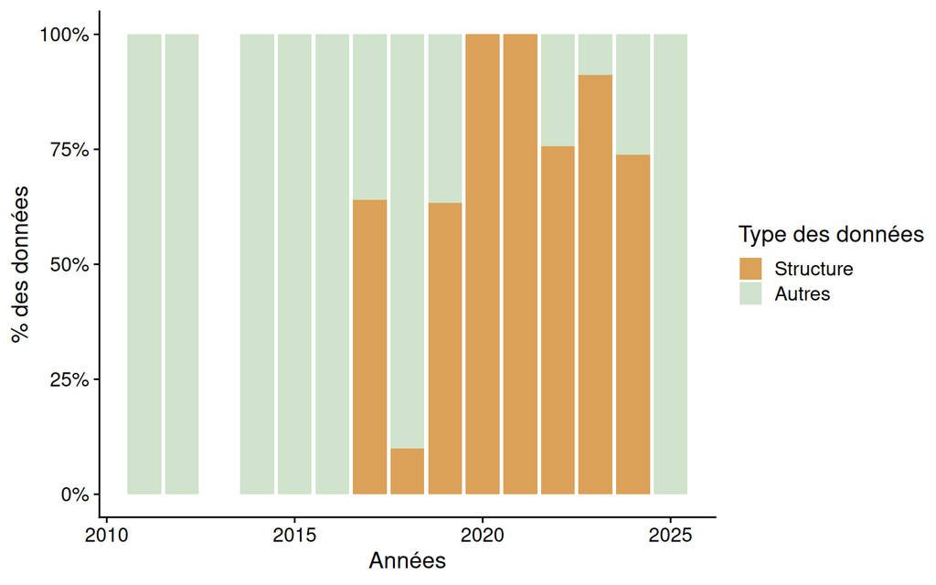

**Bords d’infrastructures**

[interactive chart not shown]

**Cimetière**

[interactive chart not shown]

**Friche**

[interactive chart not shown]

**Gazon**

[interactive chart not shown]

**Jardin**

[interactive chart not shown]

**Lisière de bois**

[interactive chart not shown]

**Prairie**

[interactive chart not shown]

**Square urbain**

[interactive chart not shown]

Chaque point rouge figure un transect de la structure. Pour un transect, on calcule sur une année l’abondance moyenne par passage et la richesse moyenne par passage. Ensuite, pour l’ensemble des années de suivi de ce transect, on calcule de nouveau la moyenne, pour obtenir une abondance moyenne par passage par année, et une richesse moyenne par passage par année. Le gradient de couleur représente le nombre d’années de suivi du transect : plus le point est foncé, plus le nombre d’années de suivi du transect est élevé.

Les points en gris représentent les transects régionaux réalisés par d’autres structures ou personnes. Pour ces points, ne sont retenus que les transects ayant suivi le protocole complet (trois passages dans l’année aux dates préconisées). Les passages réalisés hors période protocolaire ne sont pas retenus dans le calcul.

On calcule ensuite pour l’abondance moyenne et la richesse moyenne des transects protocolaires les quartiles 25%, 75% ainsi que la médiane. On représente ces valeurs à l’aide de la croix bleue. Les extrémités des segments de la croix sont les quartiles et l’intersection représente les médianes.

Ce graphique permet de situer les transects de la structure par rapport à des valeurs d’une référence régionale (croix bleue).

Pourcentage des données de la structure utilisées dans les référentiels régionaux

[interactive chart not shown]

**Habitats**

**Parc de Beaudésert**

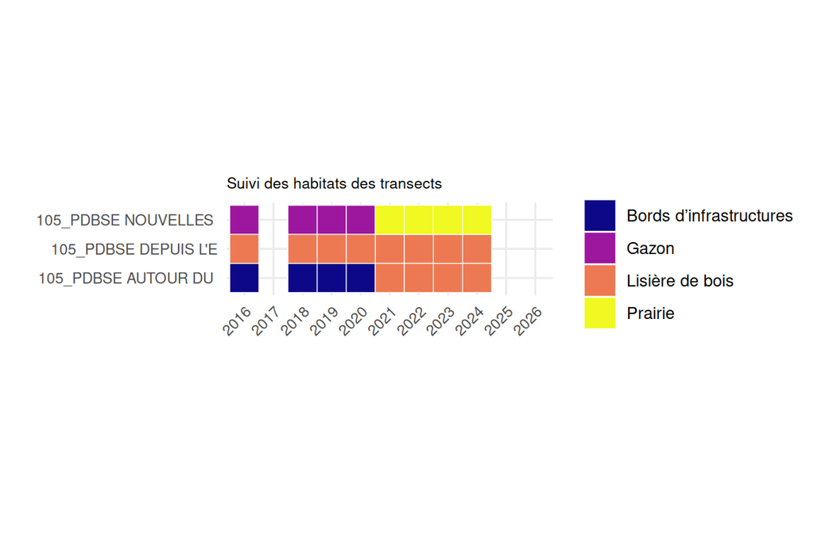

**Parc du Renard**

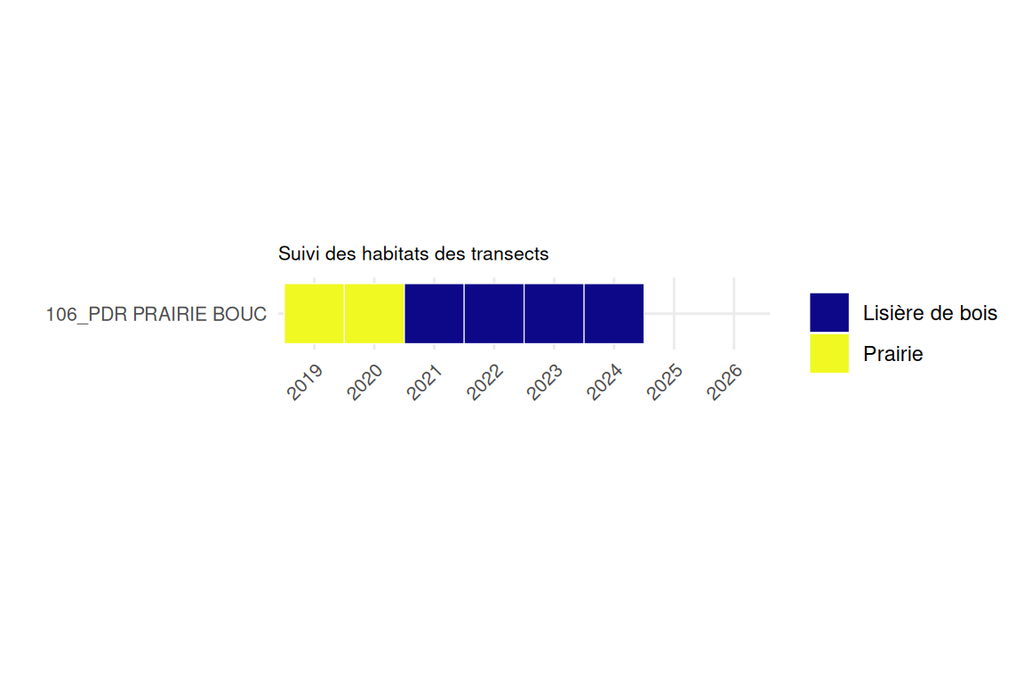

**Parc du Château**

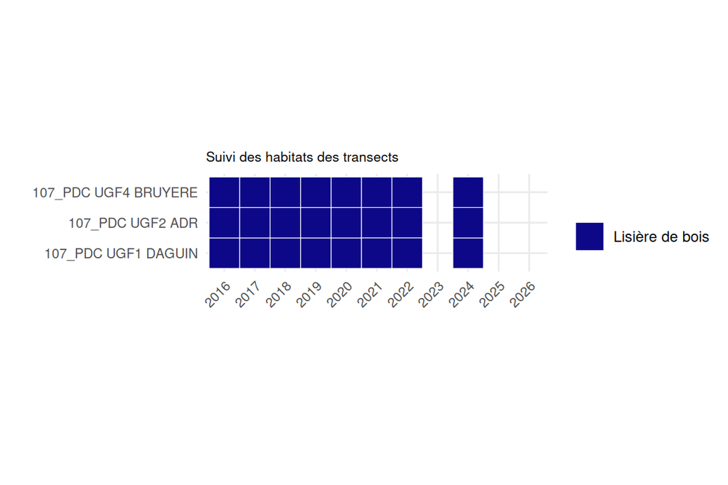

**Parc de l’Orée des deux villes**

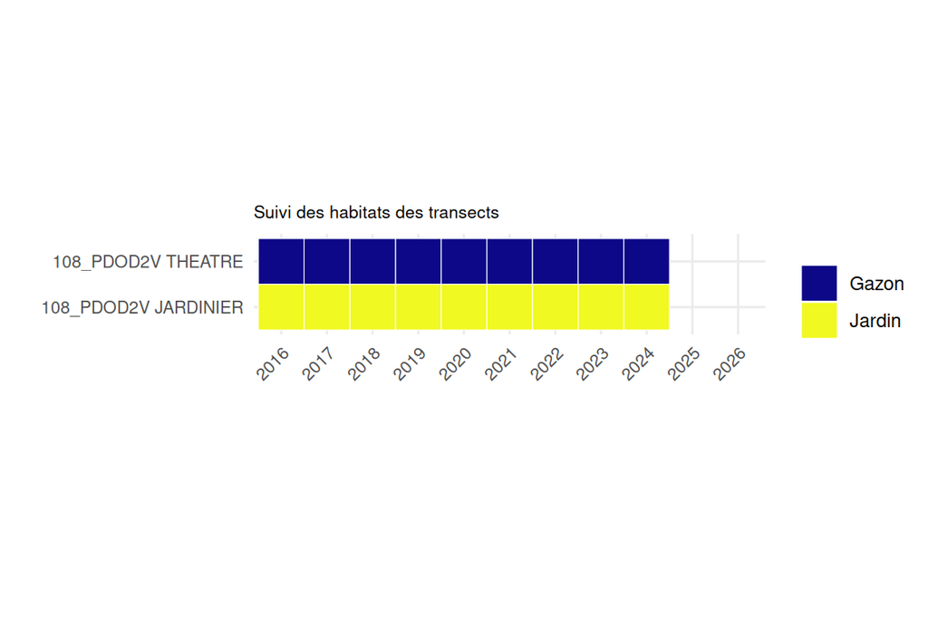

**Parc de Bourran**

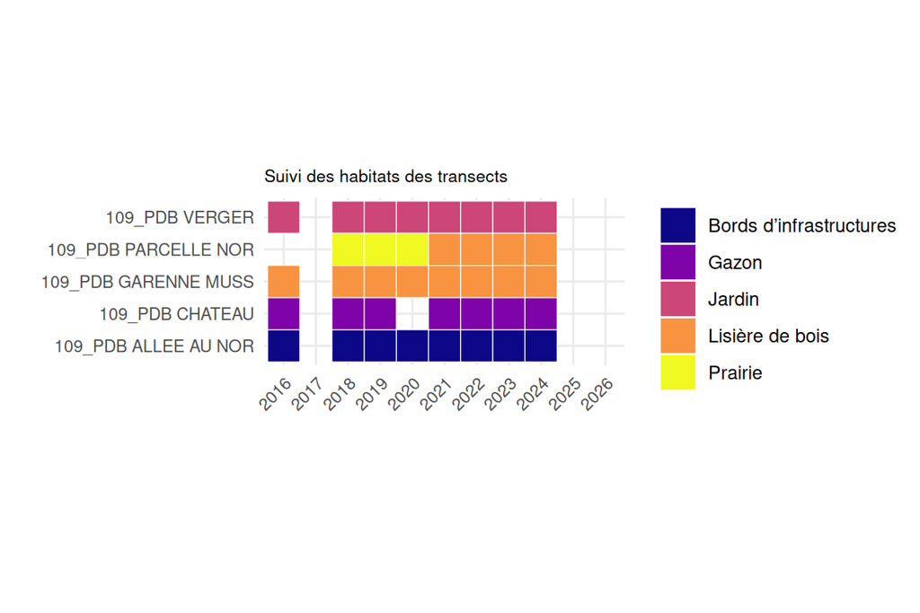

**Parc du Luchey**

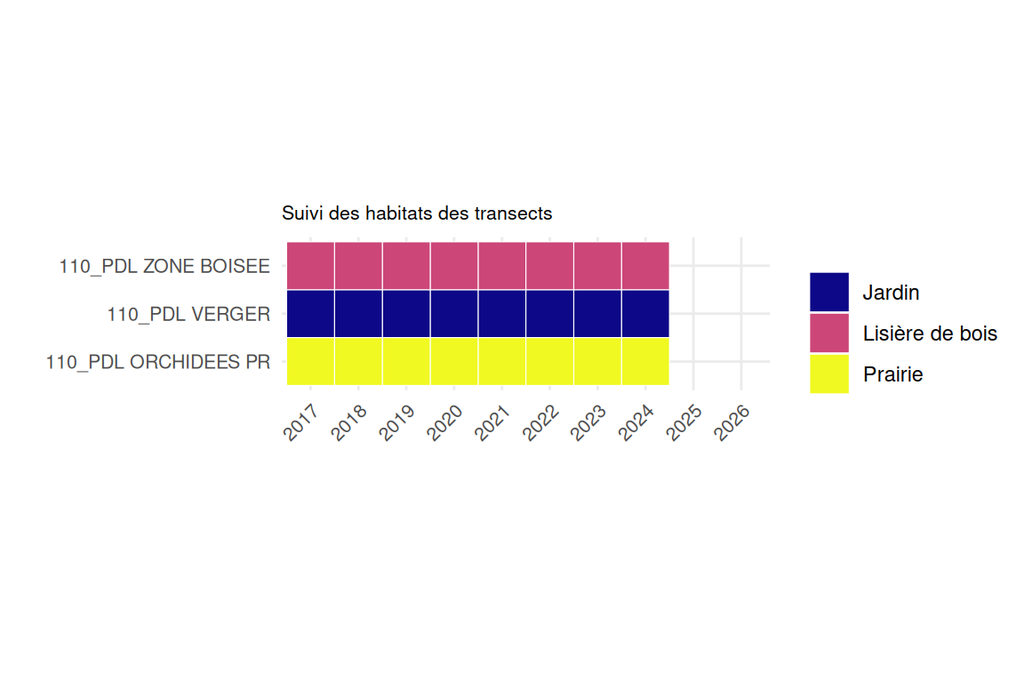

**Parc de Tenet**

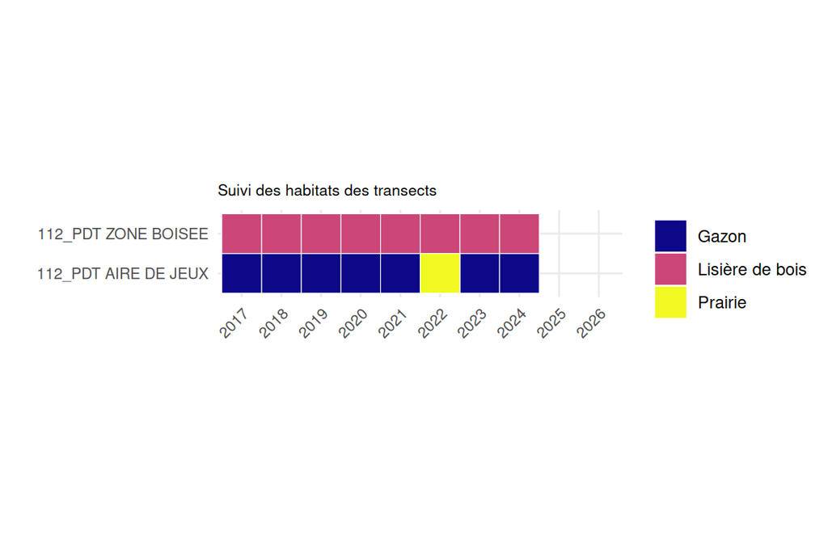

**Plaine des sports de Beutre**

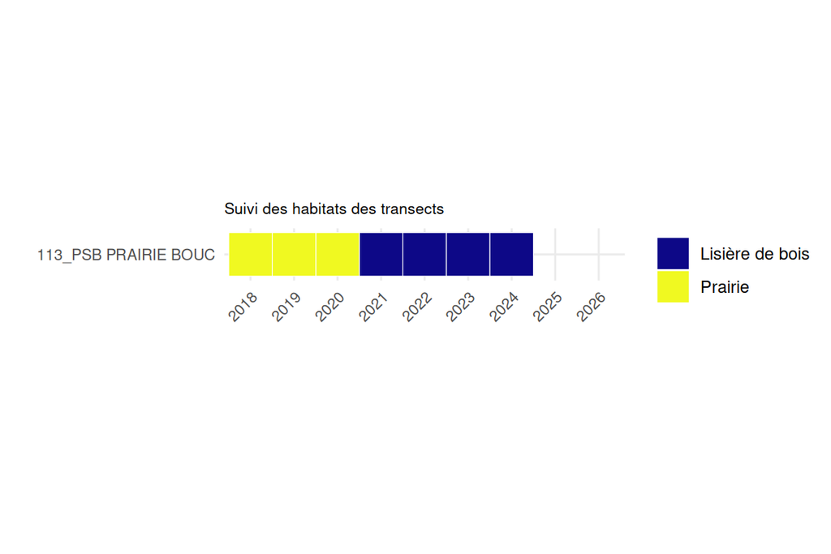

**Bois du Burck**

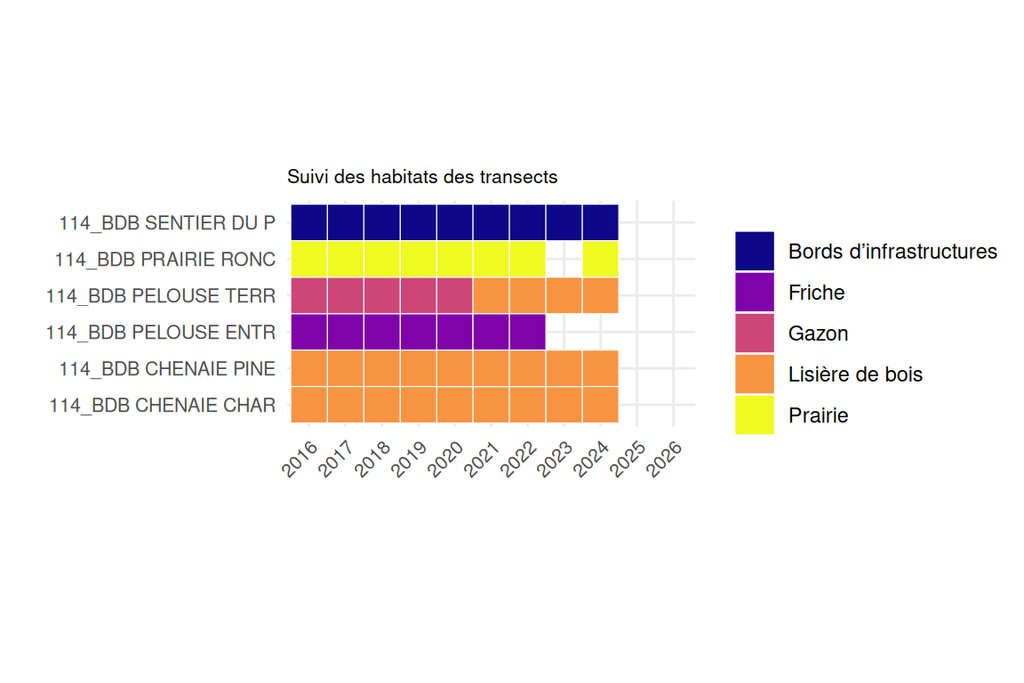

**CTE**

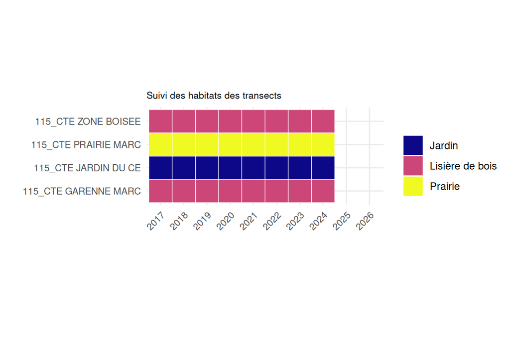

**Stade Chaban Delmas**

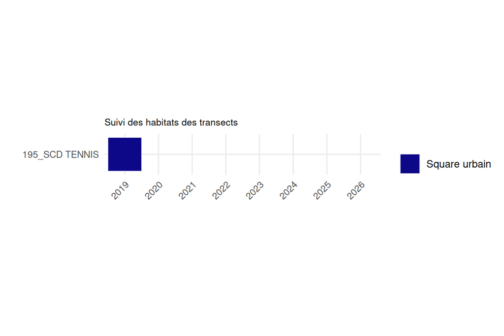

**Parc du Vivier**

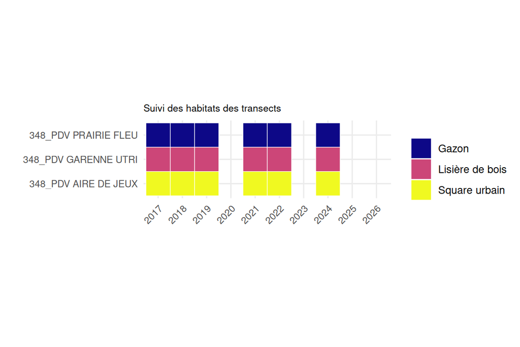

**PARC MAUBEC**

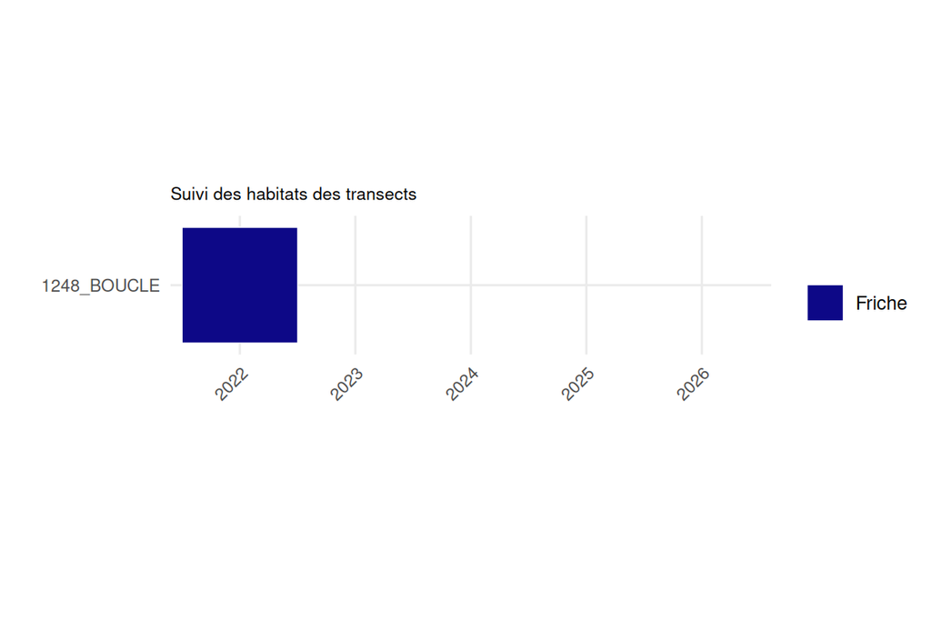

**PARC DE MARBOTIN**

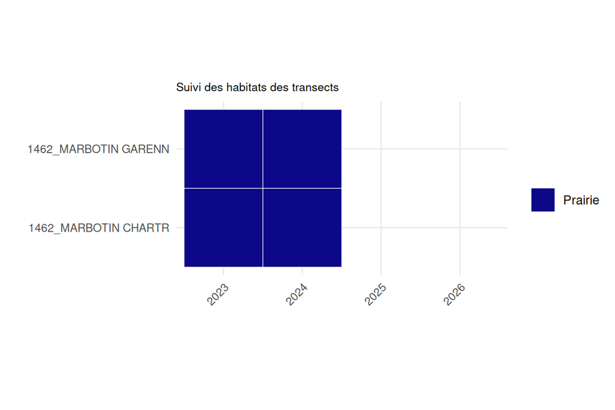

**PARC DE LA MAISON CARREE**

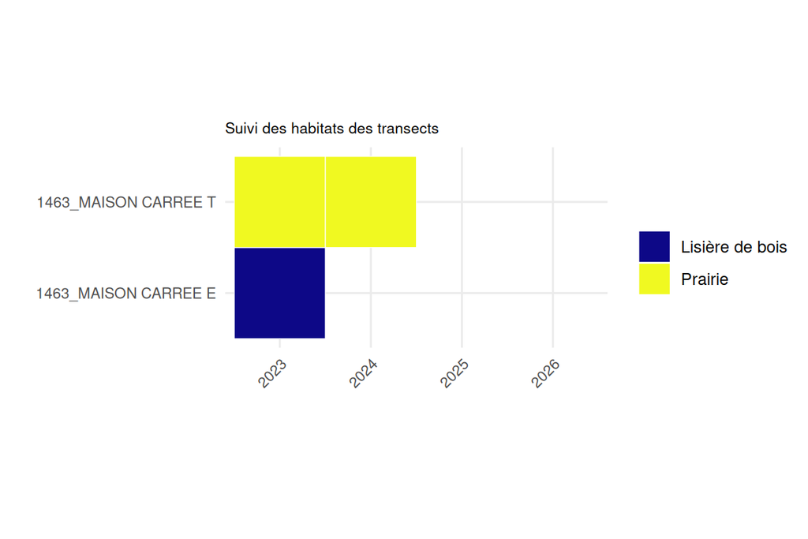

**BASSIN DE GRIMOINE**

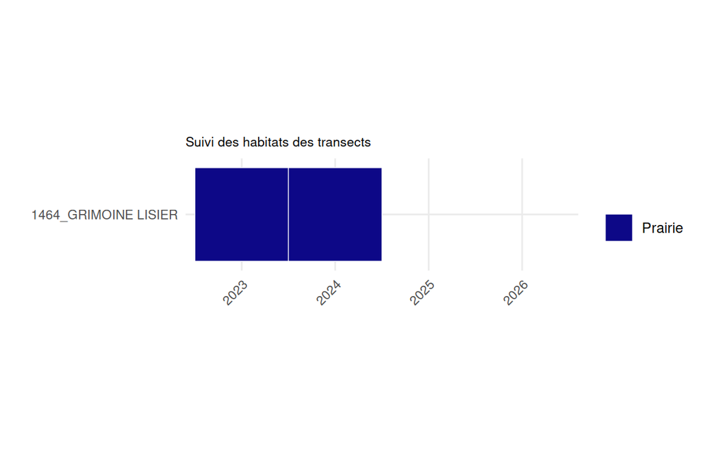

**CIMETIERE DU BOUSCAT**

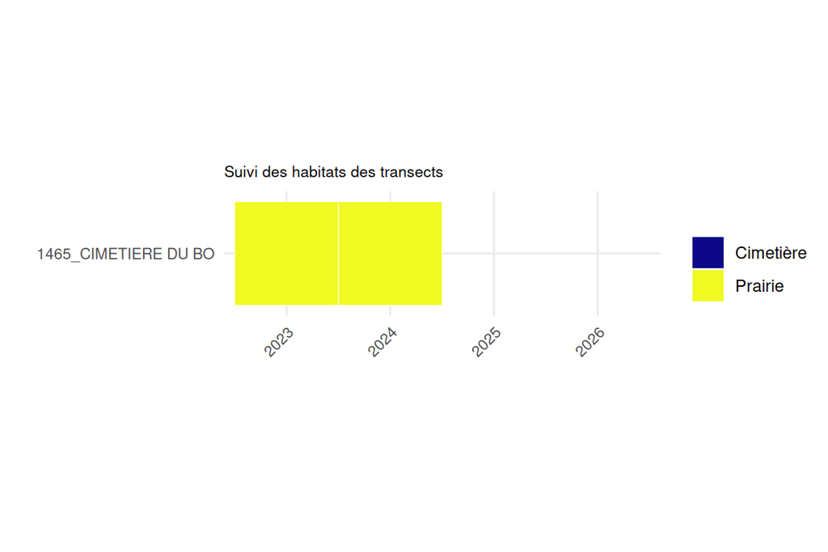

**PARC DE L’ERMITAGE**

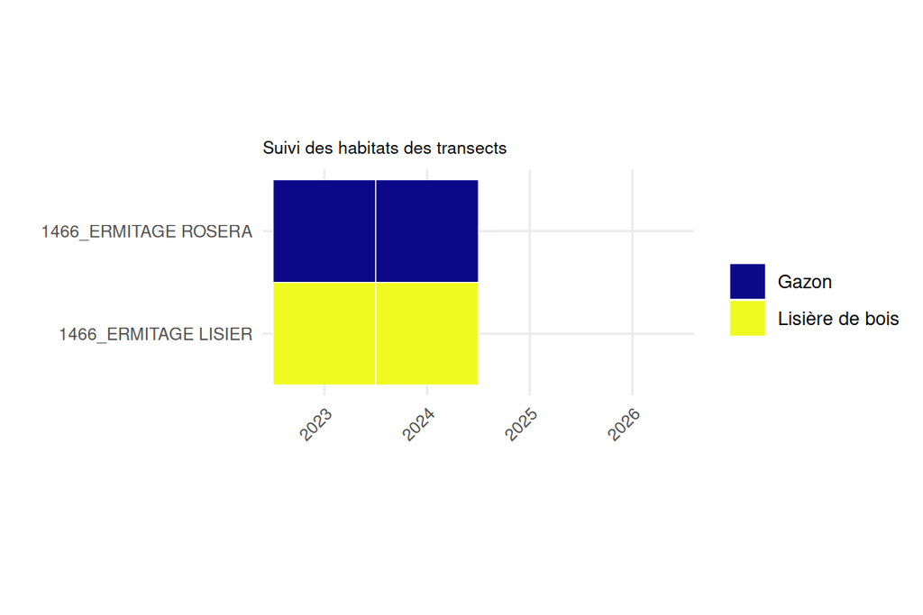

**PARC DE LA CHENERAIE**